# eQTL mapping and colocalization

23 February 2022

# 1 Functions

```r
    ### various functions

    #
    manhat = function(data, colorGN = TRUE, facetGN = FALSE) {
        p = data %>%
            ggplot(aes(mark_pos, LOD)) +
            scale_color_viridis_d() +
            theme_half_open() +
            theme(
            axis.ticks.x = element_blank(),
            axis.text.x = element_blank(),
            panel.spacing = unit(0, 'pt')
            )

        # add GN faceting
        if (facetGN) {
            p = p + facet_grid(GN~mark_chr, scales = 'free_x')
        } else {
            p = p + facet_grid(~mark_chr, scales = 'free_x')
        }

        # add color and geometry
        if (colorGN) {
            p = p + geom_step(aes(color = GN))
        } else {
            p = p + geom_step()
        }

        # output
        return(p)
    }

    #
    manhat2 = function(data, colorGN = TRUE, facetGN = FALSE, chrdiv = TRUE, chrlab = TRUE) {
        chr_ends = tibble(mark_chr = as.character(1:19) %>% fct_inorder(),
                  # mark_chr = str_c('chr', 1:19) %>% fct_inorder(),
                  pos_adj = 0:18,
                  chr_lab_pos = seq(0.5, 18.5, 1))
        chrs = data %>% pull(mark_chr) %>% unique %>% str_replace('chr', '') %>% str_sort(numeric = TRUE)
        markers = data %>%
            distinct(marker, mark_chr, mark_pos) %>%
            mutate(mark_chr = str_replace(mark_chr, 'chr', '') %>% fct_relevel(chrs)) %>%
            arrange(mark_chr) %>%
            left_join(chr_ends, by = 'mark_chr') %>%
            # min/max normalize position within each chromosome
            group_by(mark_chr) %>%
            mutate(mark_pos_ori = mark_pos) %>%
            mutate_at('mark_pos', ~(.x - min(.x))/(max(.x) - min(.x))) %>%
            ungroup %>%
            # add an integer adjustment to spread chromosomes out
            mutate(mark_pos_adj = mark_pos + pos_adj)

        # remove any conflicting columns
        drop_names = markers %>% names %>% discard(~.x == 'marker')
        data = data %>%
            select(!any_of(drop_names)) %>%
            left_join(markers, by = 'marker')

        #
        p = data %>%
            ggplot(aes(mark_pos_adj, LOD)) +
            scale_x_continuous(expand = expansion(0)) +
            scale_color_viridis_d() +
            theme_half_open() +
            theme(
                axis.ticks.x = element_blank(),
                axis.text.x = element_blank()
                # panel.spacing = unit(0, 'pt'),
            )

        if (chrdiv) p = p + geom_vline(data = chr_ends, aes(xintercept = pos_adj), linetype = 'dashed')
        if (chrlab) p = p + geom_text(data = ~.x %>% distinct(mark_chr, chr_lab_pos),
                          aes(x = chr_lab_pos, label = mark_chr), y = Inf,
                          vjust = 'inward', inherit.aes = FALSE)

        # add GN faceting
        if (facetGN) {
            p = p + facet_wrap(~GN)
        } else {
            p = p
        }

        # summarise lod thresholds if multiple
        # don't want too many lines in case multiple GNs are plotted together
        lod_thresh = data %>% summarise(thresh = mean(thresh))

        # add color and geometry
        if (colorGN) {
            p = p + geom_step(aes(color = GN)) + geom_hline(data = lod_thresh, aes(yintercept = thresh), alpha = 0.5)
        } else {
            p = p + geom_step(aes(color = mark_chr)) + geom_hline(data = lod_thresh, aes(yintercept = thresh, alpha = 0.5))
        }

        # output
        return(p)
    }
```

# 2 QTL region

```r
    ci_chr = '13'; ci_lo = 83.78112; ci_hi = 93.41913; ci_mid = 90.4
```

# 3 Reload the % expanded QTL mapping results

```r
    # load cache file
    in_cache_dir = '../data/analysis_cache/bxd_qtl_scans'
    cache_file = path(in_cache_dir, 'final_qtl.rds')
    final_res = readRDS(cache_file)

    # also load the dense chr13 qtl data
    # cache_file = path(in_cache_dir, 'perc_expand_chr13_dense_qtl.rds')
    # chr13_dense_qtl_res = readRDS(cache_file)

    # load by-epoch scan
    by_epoch_scan = readRDS(path(in_cache_dir, 'perc_expand_by_epoch_final_qtl.rds'))
```

# 4 Get founder genotypes

```r
    bxd_mark_gts = maxmarg(BXDstrs::qtl_data$snp_probs[,'13'], minprob = 0.5) %>%
        .[[1]] %>%
        as.data.frame %>%
        rownames_to_column(var = 'strain') %>%
        pivot_longer(cols = !strain, names_to = 'marker', values_to = 'fou_gt')
```

# 5 Load eQTL trace data

1. “best_trace” is a single probe worth of data for one GN/gene combination
2. “best_point” is a single LOD value for each GN/gene combination

```r
    # qtl and eqtl data objects
    eqtl_db      = readRDS('../data/gene_expr/qtl_agg/gene_expr_db.rds')
    perc_expand  = readRDS('../data/gene_expr/qtl_agg/perc_expand_db.rds')

    # remove embeded list that causes problems
    eqtl_db$probes$alig_data = NULL

    # isolate probe information
    probe_info = eqtl_db$probes %>%
        left_join(eqtl_db$signal %>% distinct(probe, gene_name), by = 'probe')

    # join probe information onto traces
    eqtl_db$signal    = eqtl_db$signal    %>% inner_join(probe_info, by = c('probe', 'gene_name'))
    eqtl_db$expr_vals = eqtl_db$expr_vals %>% inner_join(probe_info, by = c('probe', 'gene_name'))

    # load eQTL and QTL trace data for probes with snps where number of snps was used as a covariate
    eqtl_db_snps_covar   = readRDS('../data/gene_expr/qtl_agg_snps_covar/gene_expr_db.rds')
    # this one doesn't need to be redone because it is basically the same
    # perc_expand_snps_covar = readRDS('../data/gene_expr_new_wind/chr13qtl_agg_snps_covar/perc_expand_db.rds')

    # remove embeded list that causes problems
    eqtl_db_snps_covar$probes$alig_data = NULL

    # join probe information onto these traces
    eqtl_db_snps_covar$signal = eqtl_db_snps_covar$signal %>% inner_join(probe_info, by = c('probe', 'gene_name'))

    # convert position
    eqtl_db$genes = eqtl_db$genes %>% mutate(across(c(gene_pos, gene_end), ~.x/1e6))
    eqtl_db_snps_covar$genes = eqtl_db_snps_covar$genes %>% mutate(across(c(gene_pos, gene_end), ~.x/1e6))

    # check closeness of using number of snps as a covariate vs. not
    if (0) {
        left_join(
            eqtl_db_snps_covar$signal %>% select(GN, marker, probe, gene_name, LOD),
            eqtl_db$signal %>% filter(n_var_per_probe != 0) %>% select(GN, marker, probe, gene_name, LOD),
            by = c('GN', 'marker', 'probe', 'gene_name')
        ) %>% mutate(dist = LOD.x - LOD.y %>% abs) %>%
            skimr::skim(dist)
    }

    # replace eQTL traces for probes that have snps with ones computed using number of snps as a covariate
    eqtl_db$signal = bind_rows(
        eqtl_db$signal %>% filter(n_var_per_probe == 0),
        eqtl_db_snps_covar$signal
    )

    # TODO: testing this out
    # subset to only probes that don't have a variants
    # eqtl_db$signal = eqtl_db$signal %>% filter(n_var_per_probe == 0)
    # eqtl_db$expr_vals = eqtl_db$expr_vals %>% filter(n_var_per_probe == 0)

    # best point within QTL sized region around gene for each probe
    ci_hwind = (ci_hi - ci_lo)/2
    probe_max = eqtl_db$signal %>%
        left_join(eqtl_db$genes, by = 'gene_name') %>%
        left_join(eqtl_db$markers, by = 'marker') %>%
        arrange(desc(LOD)) %>%
        filter(mark_pos >= (gene_end+gene_pos)/2 - ci_hwind, mark_pos <= (gene_end+gene_pos)/2 + ci_hwind) %>%
        distinct(GN, gene_name, probe, .keep_all = TRUE) %>%
        mutate(across(where(is.factor), as.character))

    # apply p.val correction when testing multiple probes per GN/gene
    probe_max = probe_max %>%
        # distinct(GN, gene_name, probe)
        group_by(GN, gene_name) %>%
        mutate(LODadj = -log10(p.adjust(10^(-LOD), method = 'BH'))) %>%
        ungroup %>%
        mutate(is_eqtl = LODadj >= thresh)

    # check proportion of eqtl traces
    # probe_max %>% count(is_eqtl)

    # pick best probe per GN, gene_name
    # best_point = eqtl_db$signal %>%
    #   left_join(eqtl_db$genes, by = 'gene_name') %>%
    #   left_join(eqtl_db$markers, by = 'marker') %>%
    #   arrange(desc(LOD)) %>%
    #   filter(mark_pos >= (gene_end+gene_pos)/2 - ci_hwind, mark_pos <= (gene_end+gene_pos)/2 + ci_hwind) %>%
    #   distinct(GN, gene_name, probe, .keep_all = TRUE) %>%
    #   # left_join(eqtl_db$probes, by = 'probe') %>%
    #   mutate(across(where(is.factor), as.character))
    best_point = probe_max %>%
        arrange(desc(LODadj)) %>%
        distinct(GN, gene_name, .keep_all = TRUE)

    # all eqtl traces
    # apply and LOD adjustment ratio: this is account for the multiple hypothesis correction
    all_trace = eqtl_db$signal %>%
        left_join(eqtl_db$markers, by = 'marker') %>%
        left_join(probe_max %>%
                    mutate(lod_ratio = LODadj/LOD) %>%
                    select(GN, gene_name, probe, lod_ratio),
                  by = c('GN', 'gene_name', 'probe')) %>%
        mutate(LODadj = LOD*lod_ratio)

    # best trace from best point
    best_trace = all_trace %>%
        semi_join(best_point, by = c('GN', 'gene_name', 'probe'))

    # # TODO: for now remove the dense coloc stuff and redo with # snps as covariates
    # if (0) { # we aren't using these, so why load them ... keeping code around
    #   # dense eQTL data (has `coloc` analysis results)
    #   # NOTE: dense data only collected for top probe for each dset/gene only for common genes and repr datasets
    #   # dense_traces$signal %>% distinct(GN, probe, gene_name) %>% count(GN, probe, gene_name) %>% pull(n) %>% unique
    #   dense_traces = readRDS('../data/gene_expr/qtl_dense_agg/gene_expr_db.rds')
    # }
    # dense_coloc  = readRDS('../data/gene_expr/qtl_dense_agg/coloc_db.rds')

    # # TODO: testing this out
    # dense_coloc$smry    = dense_coloc$smry    %>% inner_join(probe_info, by = 'probe')
    # dense_coloc$details = dense_coloc$details %>% inner_join(probe_info, by = 'probe')

    # define DNA repair genes
    dna_repair_genes = c('Msh3', 'Xrcc4', 'Ssbp2', 'Atg10', 'Ccnh')
```

# 6 Load finalized list of selected datasets

```r
    gn_table = readRDS('../data/analysis_cache/final_gn_table.rds')
```

# 7 Subset data to list of representative GNs

```r
    # subset by dataset
    sel_dsets   = gn_table %>% select(GN = sel_dset) %>% distinct(GN) %>% filter(!is.na(GN)) %>% pull(GN)
    best_trace  = best_trace %>% filter(GN %in% sel_dsets)
    all_trace   = all_trace %>% filter(GN %in% sel_dsets)
    best_point  = best_point %>% filter(GN %in% sel_dsets)
    probe_max   = probe_max %>% filter(GN %in% sel_dsets)
    perc_expand = perc_expand$signal %>%
        filter(GN %in% sel_dsets) %>%
        left_join(perc_expand$markers, by = 'marker')

    # this is unnecessary because dense data was only collected for sel_dsets (see workflows)
    # dense_traces$signal %>% filter(GN %in% sel_dsets)

    # NOTE: only needed for manhat2 which is not used anymore
    # # figure out adjusted gene positions (for later plots where this is important)
    # pos_adj = eqtl_db$markers %>%
    #     left_join(tibble(mark_chr = str_c('chr', 1:19) %>% fct_inorder(), pos_adj = 0:18), by = 'mark_chr') %>%
    #     group_by(mark_chr, pos_adj) %>%
    #     summarise(slope = max(mark_pos) - min(mark_pos), intercept = min(mark_pos), .groups = 'drop')
    gene_info = eqtl_db$genes %>%
        # left_join(pos_adj, by = c('gene_chr' = 'mark_chr')) %>%
        # mutate(gene_pos_adj = (gene_pos - intercept)/slope + pos_adj) %>%
        arrange(gene_pos)
```

# 8 Genes

1. To check if some genes we don’t have expression data for that could drop out in this analysis

## 8.1 Annotated in EMBL

1. Types of genes in the QTL region from EMBL
2. 30 protein coding genes

```r
    embl_genes = readRDS('../data/analysis_cache/embl_genes.rds')
```

```r
    # count type of genes
    embl_genes %>% count(gene_type) %>% arrange(desc(n))
```

| gene_type | n |
| --- | --- |
| processed_pseudogene | 34 |
| protein_coding | 30 |
| TEC | 10 |
| lincRNA | 9 |
| antisense | 7 |
| miRNA | 5 |
| sense_intronic | 2 |
| snoRNA | 2 |
| misc_RNA | 1 |
| processed_transcript | 1 |

[output cut: 2 more lines]

## 8.2 Annotated in EMBL vs expression data available

```r
    # make a gene by GN matrix with indicator variable in gene is in GN from embl genes
    gene_by_gn = embl_genes %>%
        distinct(gene_name, gene_type) %>%
        left_join(best_point %>%
                  distinct(GN, gene_name) %>%
                  mutate(in_gn = 1),
            by = 'gene_name')

    # calculate number of genes per gn and number of gns per gene
    col_ord = gene_by_gn %>%
        filter(!is.na(GN)) %>%
        group_by(GN) %>%
        summarise(n_gene = gene_name %>% unique %>% length) %>%
        arrange(desc(n_gene))
    row_ord = gene_by_gn %>%
        group_by(gene_name) %>%
        summarise(n_gn = GN %>% unique %>% length) %>%
        arrange(desc(n_gn))
```

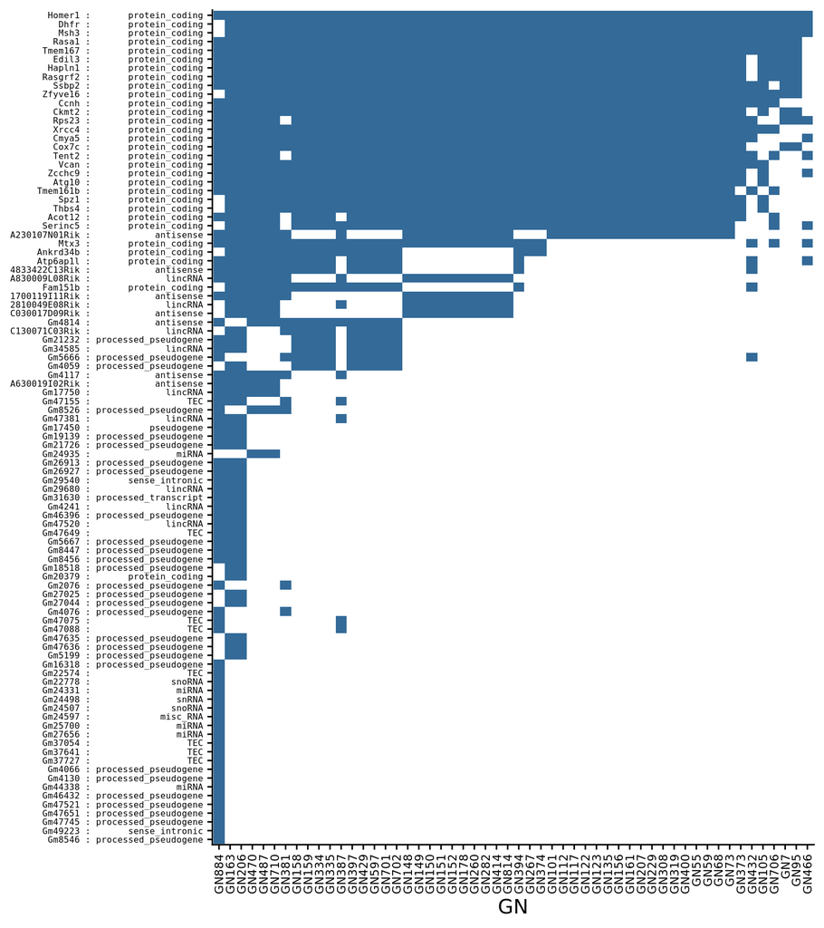

```r
    # make into gene by GN matrix and order
    p = gene_by_gn %>%
        mutate(gene_name = fct_relevel(gene_name, rev(row_ord$gene_name)),
               GN = fct_relevel(GN, col_ord$GN)) %>%
        filter(!is.na(GN)) %>%
        rowwise %>%
        mutate(y_label = str_c(gene_name, ' : ', str_pad(gene_type, 20, 'left', pad = ' '))) %>%
        ungroup %>%
        arrange(gene_name) %>%
        mutate(y_label = fct_inorder(y_label)) %>%
        ggplot(aes(GN, y_label, fill = in_gn)) +
        geom_tile() +
        theme_half_open() +
        theme(axis.text.x = element_text(angle = 90, hjust = 1, vjust = 0.5, size = 8),
              axis.text.y = element_text(size = 6, family = 'Courier'),
              axis.title.y = element_blank(),
              strip.text.y = element_text(angle = 0),
              legend.position = 'none')
    p
```

```r
    ggsave('test.pdf', p, w = 8, h = 8)
```

## 8.3 Just protein coding genes

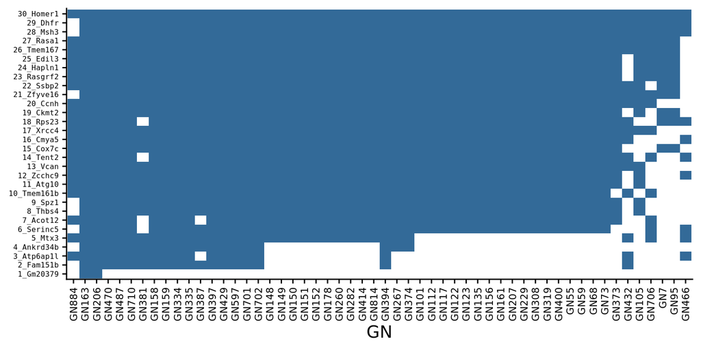

```r
    # make into gene by GN matrix and order
    p = gene_by_gn %>%
        mutate(gene_name = fct_relevel(gene_name, rev(row_ord$gene_name))) %>%
        filter(gene_type == 'protein_coding') %>%
        filter(!is.na(GN)) %>%
        pivot_wider(id_cols = c(gene_name, gene_type), names_from = GN, values_from = in_gn) %>%
        arrange(gene_name) %>%
        mutate(gene_num = 1:n()) %>%
        mutate(y_label = str_c(gene_num, '_', gene_name)) %>%
        mutate(y_label = fct_inorder(y_label)) %>%
        pivot_longer(cols = !c(gene_name, gene_type, y_label, gene_num), names_to = 'GN', values_to = 'in_gn') %>%
        mutate(GN = fct_relevel(GN, col_ord$GN)) %>%
        ggplot(aes(GN, y_label, fill = in_gn)) +
        geom_tile() +
        scale_fill_continuous(na.value = 'white') +
        theme_half_open() +
        theme(axis.text.x = element_text(angle = 90, hjust = 1, vjust = 0.5, size = 8),
              axis.text.y = element_text(size = 6, family = 'Courier'),
              axis.title.y = element_blank(),
              strip.text.y = element_text(angle = 0),
              legend.position = 'none')
    p
```

```r
    ggsave('test.pdf', p, w = 8, h = 4)
```

# 9 Subset data to list of common protein-coding genes

```r
    # subset by gene
    common_prot_genes = best_point %>%
        count(gene_name, name = 'n_gns') %>%
        left_join(gene_info %>% select(gene_name, gene_type), by = 'gene_name') %>%
        # count(is.na(gene_type))
        filter(gene_type == 'protein_coding', n_gns >= (best_point %>% pull(GN) %>% unique %>% length)/2) %>%
        pull(gene_name) %>% unique
    best_trace = best_trace %>% filter(gene_name %in% common_prot_genes)
    all_trace  = all_trace %>% filter(gene_name %in% common_prot_genes)
    best_point = best_point %>% filter(gene_name %in% common_prot_genes)
    gene_info  = gene_info %>% filter(gene_name %in% common_prot_genes)
    probe_max  = probe_max %>% filter(gene_name %in% common_prot_genes)

    # this is unnecessary because dense data was only collected for common genes (see workflows)
    # dense_traces$signal %>% filter(gene_name %in% common_prot_genes)
```

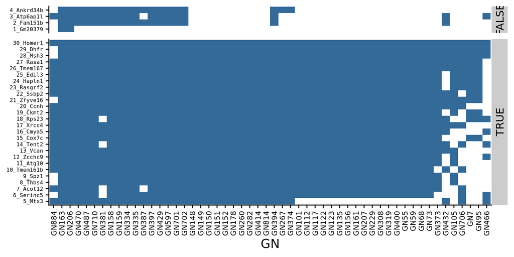

```r
    p = gene_by_gn %>%
        mutate(gene_name = fct_relevel(gene_name, rev(row_ord$gene_name))) %>%
        filter(gene_type == 'protein_coding') %>%
        filter(!is.na(GN)) %>%
        pivot_wider(id_cols = c(gene_name, gene_type), names_from = GN, values_from = in_gn) %>%
        arrange(gene_name) %>%
        mutate(gene_num = 1:n()) %>%
        mutate(y_label = str_c(gene_num, '_', gene_name)) %>%
        mutate(y_label = fct_inorder(y_label)) %>%
        pivot_longer(cols = !c(gene_name, gene_type, y_label, gene_num), names_to = 'GN', values_to = 'in_gn') %>%
        mutate(is_common_prot = gene_name %in% common_prot_genes) %>%
        mutate(GN = fct_relevel(GN, col_ord$GN)) %>%
        ggplot(aes(GN, y_label, fill = in_gn)) +
        geom_tile() +
        scale_fill_continuous(na.value = 'white') +
        facet_grid(rows = vars(is_common_prot), scales = 'free', labeller = label_value, space = 'free') +
        theme_half_open() +
        theme(axis.text.x = element_text(angle = 90, hjust = 1, vjust = 0.5, size = 8),
              axis.text.y = element_text(size = 6, family = 'Courier'),
              axis.title.y = element_blank(),
              strip.text.y = element_text(angle = 90),
              legend.position = 'none')
    p
```

```r
    ggsave('test.pdf', p, w = 8, h = 4)

    ggsave(path(plot_dir, 'Suppl_Fig_10.pdf'), p, w = 8, h = 4)
```

# 10 Visualize all traces one gene at a time (for reference)

1. Deprecated

```r
    redo = FALSE
    if (redo) {
        p_list = best_trace %>%
            nest(data = !gene_name) %>%
            # slice(1:5) %>%
            mutate(p = map2(data, gene_name, function(.x, .y) {
                p = .x %>% manhat2(colorGN = FALSE, facetGN = TRUE, chrdiv = FALSE, chrlab = FALSE) +
                    guides(color = guide_legend(nrow = 1)) +
                    theme(legend.position = 'bottom') +
                    labs(title = str_c(.y, ' : ', eqtl_db$genes %>% filter(gene_name == .y) %>% pull(gene_chr)))
                p$layers = c(geom_vline(xintercept = gene_info %>% filter(gene_name == .y) %>% pull(gene_pos_adj), linetype = 'dashed'),
                         p$layers)
                p
            }))
        # ggsave('test.pdf', p_list$p[[1]], w = 16, h = 12)

        # print into a pdf
        out_dir = 'plots'; dir_create(out_dir)
        pdf(path(out_dir, 'chr13qtl_eqtls.pdf'), w = 16, h = 12)
        map(p_list$p, print)
        dev.off()
    }
```

# 11 Collate datasets where strains support %expanded signal

```r
    strains_per_dset = BXDstrs::dset_strains %>%
        # filter in only sequenced ones
        semi_join(strain_info %>% filter(is_seq_str), by = c('strain' = 'bxd_id')) %>%
        count(GN, name = 'n_strains')
    perc_expand_smry = perc_expand %>%
        arrange(desc(LOD)) %>%
        distinct(GN, .keep_all = TRUE) %>%
        left_join(gn_table %>% select(GN = sel_dset, tissue), by = 'GN') %>%
        left_join(strains_per_dset, by = 'GN') %>%
        mutate(diff = LOD - thresh) %>%
        # mutate(GN = fct_reorder(GN, desc(diff)))
        mutate(GN = fct_reorder(GN, desc(n_strains)))
```

1. Range of number of strains per dataset: 11, 79
2. Peak LOD for %expanded phenotype for each dataset relate to permutation threshold (-)
3. Use only datasets with at least 30 strains

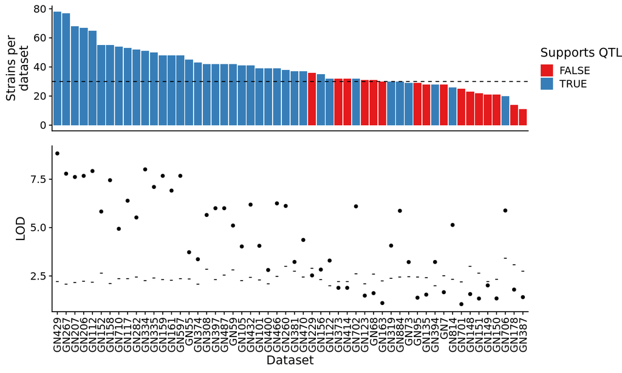

```r
    strains_per_dset_thresh = 30
    # create plot of
    p1 = perc_expand_smry %>%
        ggplot(aes(x = GN)) +
        geom_point(aes(y = LOD)) +
        geom_point(aes(y = thresh), shape = '-', size = 4) +
        theme_half_open() +
        theme(
            axis.text.x = element_text(angle = 90, vjust = 0.5, hjust = 1)
        ) +
        labs(x = 'Dataset')
    p2 = perc_expand_smry %>%
        mutate(`Supports QTL` = LOD >= thresh) %>%
        # count(`Supports QTL`)
        ggplot(aes(GN, n_strains, fill = `Supports QTL`)) +
        geom_bar(stat = 'identity') +
        geom_hline(yintercept = strains_per_dset_thresh, linetype = 'dashed') +
        scale_fill_brewer(palette = 'Set1') +
        theme_half_open() +
        theme(
            axis.text.x = element_blank(),
            axis.title.x = element_blank(),
            axis.ticks.x = element_blank()
        ) +
        labs(y = 'Strains per\ndataset')
    p = plot_grid(p2, p1, ncol = 1, axis = 'lr', align = 'v', rel_heights = c(0.6, 1))
    p
```

```r
    ggsave('test.pdf', p, w = 10, h = 6)

    # subset list
    # TODO: if we're keep the 30 strains per dataset threshold, then rename this variable
    qtl_dsets = perc_expand_smry %>%
        # filter(LOD >= thresh) %>%
        filter(n_strains >= strains_per_dset_thresh) %>%
        distinct(GN)

    # debug
    # perc_expand_smry %>%
    #   mutate(is_qtl = LOD >= thresh) %>%
    #   select(GN, n_strains, is_qtl) %>%
    #   arrange(desc(n_strains)) %>%
    #   mutate(rid = 1:n()) %>%
    #   print(n = nrow(.))

    # stat for paper
    # perc_expand_smry %>% skimr::skim(strains_per_dset)
    # perc_expand_smry %>% filter(GN == 'GN163')

    # save figure
    ggsave(path(plot_dir, 'Suppl_Fig_9.pdf'), p, w = 10, h = 6)
```

# 12 Rank genes

Various ways to rank:

1. Average maxLOD value (average value across datasets; )
2. Max maxLOD value (best LOD value across all datasets)
3. Number of datasets with maxLOD value > arbitrary threshold
4. Number of datasets with maxLOD value > perm threshold
5. Proportion of datasets with maxLOD value > perm threshold: use this

```r
    # order genes by:
    # NOTE: LOD is really maxLOD, b/c it baked into "best_point" across all markers on chr13
    top_x_genes = 10
    other_lvl = str_c('>', top_x_genes)
    gene_ord = best_point %>%
        semi_join(qtl_dsets, by = 'GN') %>%
        group_by(gene_name, gene_chr, gene_pos, gene_end) %>%
        summarise(avg_LOD = mean(LODadj),
                  max_LOD = max(LODadj),
                  n = length(GN),
                  n_over_perm_thresh = sum(LODadj >= unique(thresh)),
                  .groups = 'drop') %>%
        mutate(prop = n_over_perm_thresh/n) %>%
        # arrange(desc(.data[[c('avg_LOD', 'max_LOD', 'n_over_thresh', 'n_over_perm_thresh', 'prop')[5]]])) %>%
        # arrange(desc(prop*max_LOD)) %>%
        arrange(desc(prop)) %>%
        mutate(x = (gene_pos + gene_end)/2, y = 0, width = (gene_end - gene_pos)) %>%
        mutate(Rank = row_number()) %>%
        mutate(Rank = if_else(Rank <= top_x_genes, as.character(Rank), other_lvl)) %>%
        mutate(Rank = fct_inorder(Rank))

    # set color scale for genes
    gene_pal = RColorBrewer::brewer.pal(8, "Dark2")[1:length(dna_repair_genes)] %>% set_names(dna_repair_genes)
    other_genes = gene_ord %>%
        filter(!gene_name %in% dna_repair_genes) %>%
        pull(gene_name)
    gene_pal = c(gene_pal, gray.colors(n = length(other_genes), start = 0.2, end = 0.6) %>% set_names(other_genes))
    gene_ord = gene_ord %>% mutate(gene_col = gene_pal[gene_name])

    # print
    DT::datatable(
        gene_ord %>%
            select(gene_name, avg_LOD, max_LOD, n, n_over_perm_thresh, prop, Rank) # %>%
            # filter(gene_name %in% dna_repair_genes)
    )
```

|  | gene_name | avg_LOD | max_LOD | n | n_over_perm_thresh | prop | Rank |
| --- | --- | --- | --- | --- | --- | --- | --- |
| 1 | Ssbp2 | 8.69542518845087 | 35.3547210991012 | 39 | 29 | 0.743589743589744 | 1 |
| 2 | Atg10 | 2.9779781053397 | 12.1896906997087 | 38 | 18 | 0.473684210526316 | 2 |
| 3 | Ccnh | 3.02399325795859 | 18.2408737261022 | 39 | 14 | 0.358974358974359 | 3 |
| 4 | Cmya5 | 2.49955172179221 | 14.2581559459331 | 39 | 13 | 0.333333333333333 | 4 |
| 5 | Rasa1 | 2.01324310381687 | 14.2548335685532 | 39 | 12 | 0.307692307692308 | 5 |
| 6 | Edil3 | 1.63009749363204 | 18.1957951759264 | 38 | 6 | 0.157894736842105 | 6 |
| 7 | Tmem167 | 1.43865939087564 | 12.3388405374574 | 39 | 6 | 0.153846153846154 | 7 |
| 8 | Xrcc4 | 1.16511469748417 | 5.47543422979245 | 39 | 6 | 0.153846153846154 | 8 |
| 9 | Thbs4 | 0.784689593285631 | 5.13664954893933 | 37 | 5 | 0.135135135135135 | 9 |
| 10 | Tent2 | 1.12634015750642 | 5.32992559889843 | 38 | 5 | 0.131578947368421 | 10 |

[output cut: 16 more lines]

# 13 Collate a list of dsets/genes with eQTL signal

1. eQTL signal has to pass threshold within a QTL sized window around each gene

```r
    # NOTE: best_point already restricted to QTL sized region around gene position (see "Load eQTL trace data" above)
    # want to keep probe in this list as well, b/c we may need to access the specific probe where GN/gene_name pair has an eQTL
    eqtl_dsets_genes = best_point %>%
        # group_by(gene_name) %>% skimr::skim(mark_pos) %>% as_tibble %>% arrange(numeric.p50)
        semi_join(qtl_dsets, by = 'GN') %>%
        group_by(GN, gene_name) %>%
        filter(LODadj >= unique(thresh)) %>%
        ungroup %>%
        select(GN, gene_name, probe)
```

# 14 LOD vs LODadj

```r
    eg = eqtl_dsets_genes %>% filter(gene_name == 'Msh3') %>% slice(1)
    p1 = probe_max %>%
        semi_join(eg, by = c('GN', 'gene_name')) %>%
        select(GN, gene_name, probe, maxLOD = LOD, maxLODadj = LODadj, thresh) %>%
        arrange(desc(maxLODadj)) %>%
        mutate(ord = 1:n()) %>%
        ungroup %>%
        pivot_longer(cols = c(maxLOD, maxLODadj), names_to = 'var', values_to = 'val') %>%
        ggplot() +
        geom_point(aes(probe, val, color = var)) +
        geom_point(data = ~.x %>% distinct(GN, gene_name, probe, thresh),
                   shape = '-', aes(probe, thresh), color = 'black') +
        geom_text_repel(data = ~.x %>% filter(ord == 1, var == 'maxLODadj'),
                        aes(x = probe, y = val, label = sprintf('best probe: %s', probe)),
                        min.segment.length = 0) +
        scale_x_discrete(guide = guide_axis(check.overlap = TRUE)) +
        facet_wrap(~GN+gene_name, labeller = label_both) +
        theme_half_open() +
        theme(axis.text.x = element_text(angle = 90, hjust = 1, vjust = 0.5))
    p2 = best_trace %>%
        semi_join(eg, by = c('GN', 'gene_name', 'probe')) %>%
        pivot_longer(cols = c(LOD, LODadj), names_to = 'var', values_to = 'val') %>%
        ggplot(aes(mark_pos, val, color = var)) +
        geom_step() +
        scale_color_brewer(palette = 'Set1') +
        facet_wrap(~probe, labeller = label_both) +
        theme_half_open()
    p = plot_grid(p1, p2, ncol = 1)
    ggsave('test.pdf', p, w = 8, h = 6)
```

# 15 Run detailed eQTL mapping for Msh3 only with **all** variants

```r
    # load vep data
    vep_data = readRDS('../data/analysis_cache/annot/vep_data.rds')
    loci_gts = vep_data$loci_gts

    # gene expression data
    # expr_vals = readRDS('../data/gene_expr/qtl_agg/gene_expr_db.rds')$expr_vals
    expr_vals = eqtl_db$expr_vals %>% select(GN, probe, gene_name, strain, expr_val)

    # load probe info
    vars_per_probe_strain = readRDS('../data/gene_expr/vars_per_probe_strain.rds')

    # subset expression values and join number of variants per probe/strain combination as a covariate
    expr_vals = expr_vals %>%
        semi_join(eqtl_dsets_genes, by = c('GN', 'gene_name', 'probe')) %>%
        left_join(vars_per_probe_strain, by = c('probe', 'strain')) %>%
        mutate(n_var = replace_na(n_var, 0))

    # check
    if (0) {
        expr_vals %>% count(n_var)
        # n_var     n
        #     0  6780
        #     1   101
        #     2     2
        #     4     1
        #     5     1
        #     7    16
        #    11     3

        # eqtl probes from Msh3 don't have variants anyway
        expr_vals %>% filter(gene_name == 'Msh3') %>% count(n_var)
        # n_var     n
        #     0   15

        # check combinations
        expr_vals %>% distinct(GN, gene_name)
    }

    # subset just to Msh3
    expr_vals = expr_vals %>% filter(gene_name == 'Msh3')

    # run association testing
    cache_dir = '../data/analysis_cache'; dir_create(cache_dir)
    cache_file = path(cache_dir, 'eqtl_detailed.rds'); redo = FALSE
    if (!file_exists(cache_file) | redo) {
        # standard lm way
        nested_loci_gts = loci_gts %>%
            filter(!is.na(GT_A)) %>%
            mutate(GT_T = GT_A + GT_B) %>%
            left_join(expr_vals, by = 'strain') %>%
            filter(!is.na(expr_val)) %>%
            nest(data = !c(GN, probe, gene_name, loc_type, loc_id))
        # get some test data
        # locus_data = nested_loci_gts %>%
        #     filter(loc_type == 'snp') %>%
        #     slice_sample(n = 1) %>% pull(data) %>% .[[1]]
        # locus_data = nested_loci_gts %>% filter(pos == 88825954) %>% pull(data) %>% .[[1]]
        # type = 'aov'
        fit_lm = function(locus_data, type = c('linear', 'aov')) {
            if (type == 'linear') {
                lm(expr_val ~ GT_T + n_var, data = locus_data) %>% broom::tidy() %>%
                    filter(term == 'GT_T') %>% select(p.value)
            } else if (type == 'aov') {
                anova(lm(expr_val ~ gt + n_var, data = locus_data)) %>%
                    broom::tidy() %>% filter(term == 'gt') %>% select(p.value)
            }
        }
        # fit_lm(locus_data, 'linear')
        # fit_lm(locus_data, 'aov')

        # run for all loci
        library(progress)
        pb <- progress_bar$new(total = nested_loci_gts %>% nrow)
        assoc_test = nested_loci_gts %>%
            mutate(lm_fit = map2(data, loc_id, function(.x, .y) {
                pb$tick()
                # print(.y)
                ret = try(fit_lm(.x, 'aov'), silent = TRUE)
                if (class(ret) != 'try-error') {
                    return(ret)
                } else {
                    return(tibble(p.value = NA))
                }
            }))
        assoc_test = assoc_test %>% select(!data) %>% unnest(lm_fit)

        # save cache
        saveRDS(assoc_test, cache_file)
    } else {
        assoc_test = readRDS(cache_file)
    }

    # check if association was run for all loci
    if (!all_equal(
        # loci_gts %>% distinct(loc_type, chr, pos, end),
        # assoc_test %>% distinct(loc_type, chr, pos, end)
        loci_gts %>% distinct(loc_type, loc_id),
        assoc_test %>% distinct(loc_type, loc_id)
        )) stop('Association tests missing')

    # check
    # assoc_test %>% distinct(GN, probe, gene_name)

    # join allele frequency information; discard intercept
    assoc_test = assoc_test %>% filter(!is.na(p.value))
```

# 16 Data at this point

1. `final_res`: QTL mapping for %expanded mutator pheno using all strains
2. `perc_expand`: QTL traces for %expanded mutator pheno per dset, where only strains from that dset were used
   - Filtered for representative datasets and common genes
3. `best_trace`: best eQTL traces per dset/gene (one single probe among many for a gene)
   - Filtered for representative datasets and common genes
4. `best_point`: max LOD value per dset/gene **within QTL region** (i.e. max value of each best trace)
   - Filtered for representative datasets and common genes
5. `probe_max`: max LOD for each GN/gene/probe combination
   - Filtered for representative datasets and common genes
6. `dense_traces` and `dense_coloc`: eQTL and eQTL/QTL COLOC results for dense marker data
   - Only common genes
   - Only representative genes
   - Only dset/gene pairs with eQTL signal
   - Only top probe per dset/gene pair
7. `qtl_dsets`: dataset that support QTL rediscovery
8. `eqtl_dsets_genes`: dset/gene pairs where an eQTL was found

# 17 Best eQTL LOD per gene/dset

## 17.1 Version 1 (all GN dsets)

1. Rank genes by proportion of datasets where LOD greater than permutation threshold
2. NOTE 02/01/22: removing printing of this

```r
    # order GN datasets by number of genes for which QTL results are available
    dset_ord = best_point %>%
        group_by(GN) %>%
        summarise(N = length(gene_name), .groups = 'drop') %>%
        arrange(N)

    # heatmap of maxLOD
    # try different ways to order genes and pick one for production
    mid_point = 3/(best_point %>% pull(LOD) %>% max)*4
    # ord_by = 'prop'
    p_list = map(list('avg_LOD', 'max_LOD', 'n_over_perm_thresh', 'prop') %>% set_names(.), function(ord_by) {
        gene_lvls = gene_ord %>% arrange(desc(.data[[ord_by]])) %>% pull(gene_name)

        # check Msh3 rank
        # which(gene_lvls == 'Msh3') %>% print

        p = best_point %>%
            mutate(gene_name = fct_relevel(gene_name, gene_lvls)) %>%
            mutate(GN = fct_relevel(GN, dset_ord %>% pull(GN))) %>%
            left_join(gn_table %>% select(GN = sel_dset, tissue), by = 'GN') %>%
            # mutate(above_thresh = as.integer(LODadj >= lod_thresh)) %>%
            ggplot(aes(gene_name, GN, fill = LODadj)) +
            geom_tile() +
            geom_vline(xintercept = (top_x_genes + 0.5)) +
            scale_fill_distiller(palette = 'Purples',
                     direction = 1,
                     breaks = scales::breaks_width(width = 3),
                     # values = c(0, mid_point, 1),
                     guide = guide_colorbar(title = 'maxLOD', barheight = unit(0.5, 'npc'))
                     ) +
            scale_y_discrete(position = 'right') +
            facet_grid(tissue~., scales = 'free_y', space = 'free', switch = 'y') +
            theme_half_open() +
            theme(
              legend.position = 'left',
              axis.text.x = element_text(angle = 60, hjust = 1),
              panel.background = element_rect(fill = 'gray50'),
              strip.text.y.left = element_text(angle = 0),
              strip.placement = 'inside',
              panel.spacing.y = unit(2, 'pt')
            ) +
            labs(x = 'Gene Name')
        p # + labs(title = ord_by)
    })
    # p = plot_grid(plotlist = p_list, nrow = 2)
    # ggsave('test.pdf', p, w = 14*2, h = 10*2) # for trip panel

    p = p_list$prop

    # print
    # p
    # ggsave('test.pdf', p, w = 14, h = 10)
```

## 17.2 Version 2 (only dataset with QTL signal)

1. Only dataset that have a %expanded QTL signal
2. NOTE 02/01/22: removing printing of this

```r
    to_plt = best_point %>%
        mutate(gene_name = fct_relevel(gene_name, gene_ord %>% arrange(desc(prop)) %>% pull(gene_name))) %>%
        mutate(GN = fct_relevel(GN, dset_ord %>% pull(GN))) %>%
        left_join(gn_table %>% select(GN = sel_dset, tissue), by = 'GN') %>%
        semi_join(qtl_dsets, by = 'GN')
    p_filt = p %+% to_plt
    p_filt
    ggsave('test.pdf', p_filt, w = 14, h = 10)
```

## 17.3 Version 3 (only datasets with QTL signal) and binned colorization

```r
    to_plt = best_point %>%
        mutate(gene_name = fct_relevel(gene_name, gene_ord %>% arrange(desc(prop)) %>% pull(gene_name))) %>%
        left_join(gn_table %>% select(GN = sel_dset, tissue), by = 'GN') %>%
        mutate(GN = fct_relevel(GN, dset_ord %>% pull(GN))) %>%
        semi_join(qtl_dsets, by = 'GN')
    p_filt = ( p %+% to_plt ) +
        scale_fill_fermenter(palette = 'Purples',
                 direction = 1,
                 breaks = c(0, 3.5, 5, 10),
                 guide = guide_colorsteps(title = 'maxLOD', barheight = unit(0.5, 'npc'))
        )
    p_filt
```

[figure not shown]

```r
    ggsave('test.pdf', p_filt, w = 14, h = 10)

    ggsave(path(plot_dir, 'Suppl_Fig_12.pdf'), p_filt, w = 14, h = 10)
```

# 18 Genes in the %expanded QTL region

```r
    genes_qtl_plot = function(qtl_data, color_by = NULL) {
        # manual color scale
        # coul = c(colorRampPalette(RColorBrewer::brewer.pal(9, "PRGn"))(top_x_genes), 'gray30')
        # confidence interval around QTL from 2_mutator_pheno_scan.Rmd using 1.5 LOD drop method
        gene_h = 0.1
        yl = 2.5
        xlims = c(ci_lo-3, ci_hi+3)

        p = gene_ord %>%
            arrange(gene_pos, gene_end) %>%
            mutate(y = (yl+0.1)+IRanges::disjointBins(IRanges::IRanges(gene_pos, gene_end))*gene_h*1.2) %>%
            mutate(hlite = if_else(gene_name %in% dna_repair_genes, gene_name, NA_character_)) %>%
            ggplot(aes(x = x, y = y, width = width, height = gene_h)) +
            geom_rect(aes(xmin = ci_lo, xmax = ci_hi, ymin = -Inf, ymax = Inf), fill = 'gray90') +
            geom_step(data = qtl_data, aes(pos, LOD), inherit.aes = FALSE) +
            geom_vline(xintercept = ci_mid, linetype = 'dashed') +
            geom_text_repel(data = ~.x %>% filter(Rank != other_lvl | gene_name %in% dna_repair_genes),
                            aes(label = gene_name,
                                fontface = if_else(!is.na(hlite), 'bold', 'plain'),
                                color = gene_name
                            ),
                            force_pull   = 0, # do not pull toward data points
                            nudge_y      = 0,
                            direction    = "x",
                            angle        = 90,
                            hjust        = 0,
                            segment.size = 0.2,
                            ylim         = c(yl+1.5, NA),
                            max.overlaps = Inf
                            ) +
            geom_tile(color = NA, alpha = 1) +
            coord_cartesian(xlim = xlims, ylim = c(yl, NA)) +
            # scale_color_brewer(palette = 'Dark2', na.value = 'gray50') +
            scale_color_manual(values = gene_pal) +
            scale_x_continuous(breaks = scales::breaks_width(width = 2)) +
            theme_half_open() +
            theme(legend.position = 'none') +
            labs(x = 'Mb', y = 'LOD')
        p
    }

    genes_qtl_plot_mult_traces = function(qtl_data) {
        # manual color scale
        # coul = c(colorRampPalette(RColorBrewer::brewer.pal(9, "PRGn"))(top_x_genes), 'gray30')
        # confidence interval around QTL from 2_mutator_pheno_scan.Rmd using 1.5 LOD drop method
        # gene_h = 0.1
        # yl = 0
        # xlims = c(ci_lo-3, ci_hi+3)
        # upshift = 1.5

        # p = gene_ord %>%
        #   arrange(gene_pos, gene_end) %>%
        #   mutate(y = (yl+upshift)+IRanges::disjointBins(IRanges::IRanges(gene_pos, gene_end))*gene_h*1.2) %>%
        #   mutate(hlite = if_else(gene_name %in% dna_repair_genes, gene_name, NA_character_)) %>%
        #   ggplot(aes(x = x, y = y, width = width, height = gene_h)) +
        #   geom_rect(aes(xmin = ci_lo, xmax = ci_hi, ymin = -Inf, ymax = Inf), fill = 'gray90') +
        #   geom_step(data = qtl_data, aes(pos, LOD, linetype = epoch_grp), inherit.aes = FALSE) +
        #   geom_vline(xintercept = ci_mid, linetype = 'dashed') +
        #   geom_text_repel(data = ~.x %>% filter(Rank != other_lvl | gene_name %in% dna_repair_genes),
        #                   aes(label = gene_name,
        #                       fontface = if_else(!is.na(hlite), 'bold', 'plain'),
        #                       color = gene_name
        #                   ),
        #                   force_pull   = 0, # do not pull toward data points
        #                   nudge_y      = 0,
        #                   direction    = "x",
        #                   angle        = 90,
        #                   hjust        = 0,
        #                   segment.size = 0.2,
        #                   ylim         = c(yl+upshift+1.5, NA),
        #                   max.overlaps = Inf
        #                   ) +
        #   geom_tile(color = NA, alpha = 1) +
        #   coord_cartesian(xlim = xlims, ylim = c(yl, NA)) +
        #   # scale_color_brewer(palette = 'Dark2', na.value = 'gray50') +
        #   scale_color_manual(values = gene_pal, guide = NULL) + # don't show this legend
        #   scale_x_continuous(breaks = scales::breaks_width(width = 2)) +
        #   theme_half_open() +
        #   theme(legend.position = 'right') +
        #   labs(x = 'Mb', y = 'LOD')

        gene_h = 0.1
        yl = 0
        yu = 1.75
        xlims = c(ci_lo-3, ci_hi+3)
        upshift = 0.8

        p1 = gene_ord %>%
            arrange(gene_pos, gene_end) %>%
            mutate(y = yl+IRanges::disjointBins(IRanges::IRanges(gene_pos, gene_end))*gene_h*1.2) %>%
            mutate(hlite = if_else(gene_name %in% dna_repair_genes, gene_name, NA_character_)) %>%
            ggplot(aes(x = x, y = y, width = width, height = gene_h)) +
            geom_text_repel(data = ~.x %>% filter(Rank != other_lvl | gene_name %in% dna_repair_genes),
                            aes(label = gene_name,
                                fontface = if_else(!is.na(hlite), 'bold', 'plain'),
                                color = gene_name
                            ),
                            size         = 3.5,
                            force_pull   = 0, # do not pull toward data points
                            nudge_y      = 0,
                            direction    = "x",
                            angle        = 90,
                            hjust        = 0,
                            segment.size = 0.2,
                            ylim         = c(yl+upshift, NA),
                            max.overlaps = Inf
                            ) +
            geom_tile(color = NA, alpha = 1) +
            coord_cartesian(xlim = xlims, ylim = c(yl, yu)) +
            scale_color_manual(values = gene_pal) +
            scale_x_continuous(breaks = scales::breaks_width(width = 2)) +
            theme_half_open() +
            theme(legend.position = 'none',
                  # axis.title.y  = element_blank(),
                  axis.text.y     = element_blank(),
                  axis.ticks.y    = element_blank(),
                  axis.title.x    = element_blank(),
                  axis.text.x     = element_blank(),
                  axis.ticks.x    = element_blank()
            ) +
            labs(y = 'Genes')
        p2 = qtl_data %>%
            ggplot() +
            geom_rect(aes(xmin = ci_lo, xmax = ci_hi, ymin = -Inf, ymax = Inf), fill = 'gray90') +
            geom_step(data = qtl_data, aes(pos, LOD, color = epoch_grp), inherit.aes = FALSE) +
            geom_vline(xintercept = ci_mid, linetype = 'dashed') +
            coord_cartesian(xlim = xlims, ylim = c(yl, NA)) +
            scale_color_brewer(palette = 'Dark2', na.value = 'gray50', guide = guide_legend(title = 'Epoch')) +
            scale_x_continuous(breaks = scales::breaks_width(width = 2)) +
            theme_half_open() +
            theme(legend.position = 'right') +
            labs(x = 'Mb', y = 'LOD')
        p = plot_grid(p1, p2, ncol = 1, axis = 'lr', align = 'v', rel_heights = c(0.4, 1))
        p
    }
```

## 18.1 Sparse marker array

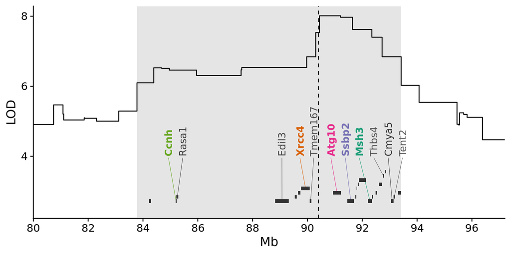

```r
    p = final_res$qtl_res %>%
        filter(metric == '% expanded', chr == 'chr13') %>%
        mutate(across(c(pos, end), ~.x/1e6)) %>%
        genes_qtl_plot
    p
```

```r
    ggsave('test.pdf', p, w = 8, h = 4)

    p_b = p
```

## 18.2 Dense marker array

1. DEPRECATED

```r
    # NOTE: chr13_dense_qtl_res is just for the "proportion_expanded" metric and only for chr13
    p = chr13_dense_qtl_res %>%
        filter(genoprobs == 'dense') %>%
        mutate(across(c(pos, end), ~.x/1e6)) %>%
        genes_qtl_plot
    p
    ggsave('test.pdf', p, w = 8, h = 4)
```

## 18.3 Individual trace by epoch

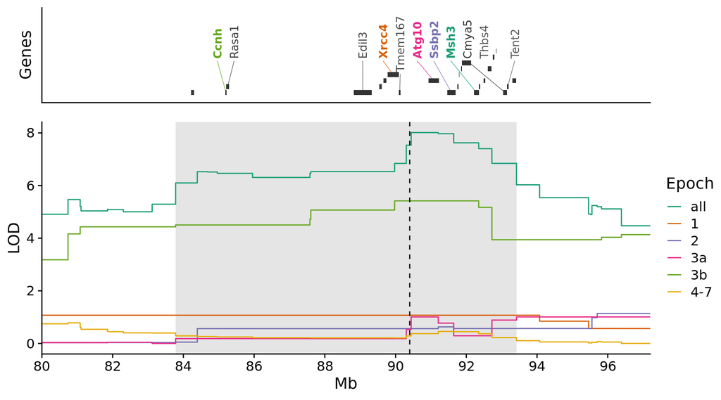

```r
    # NOTE: only % expanded was scanned in this case
    p = by_epoch_scan %>%
        filter(chr == 'chr13') %>%
        mutate(epoch_grp = fct_relevel(epoch_grp, c('all', '1', '2', '3a', '3b', '4-7', '2,3b'))) %>%
        filter(epoch_grp != '2,3b') %>%
        mutate(across(c(pos, end), ~.x/1e6)) %>%
        genes_qtl_plot_mult_traces
    p
```

```r
    ggsave('test.pdf', p, w = 9, h = 5)
```

## 18.4 Links to info on genes in the region

```r
    make_links = function(symbol) {
        gene_cards = sprintf('https://www.genecards.org/cgi-bin/carddisp.pl?gene=%s&keywords=%s#pathways_interactions', symbol, symbol)
        sprintf('%s: <a href=%s>gene_cards</a>', symbol, gene_cards)
    }
    gene_ord %>%
        select(gene_name) %>%
        rowwise %>%
        mutate(gene_name = make_links(gene_name)) %>%
        ungroup %>%
        mutate(rid = 1:n()) %>% relocate(rid, .before = 1) %>%
        knitr::kable(.)
```

| rid | gene_name |
| --- | --- |
| 1 | Ssbp2: [gene_cards](https://www.genecards.org/cgi-bin/carddisp.pl?gene=Ssbp2&keywords=Ssbp2#pathways_interactions) |
| 2 | Atg10: [gene_cards](https://www.genecards.org/cgi-bin/carddisp.pl?gene=Atg10&keywords=Atg10#pathways_interactions) |
| 3 | Ccnh: [gene_cards](https://www.genecards.org/cgi-bin/carddisp.pl?gene=Ccnh&keywords=Ccnh#pathways_interactions) |
| 4 | Cmya5: [gene_cards](https://www.genecards.org/cgi-bin/carddisp.pl?gene=Cmya5&keywords=Cmya5#pathways_interactions) |
| 5 | Rasa1: [gene_cards](https://www.genecards.org/cgi-bin/carddisp.pl?gene=Rasa1&keywords=Rasa1#pathways_interactions) |
| 6 | Edil3: [gene_cards](https://www.genecards.org/cgi-bin/carddisp.pl?gene=Edil3&keywords=Edil3#pathways_interactions) |
| 7 | Tmem167: [gene_cards](https://www.genecards.org/cgi-bin/carddisp.pl?gene=Tmem167&keywords=Tmem167#pathways_interactions) |
| 8 | Xrcc4: [gene_cards](https://www.genecards.org/cgi-bin/carddisp.pl?gene=Xrcc4&keywords=Xrcc4#pathways_interactions) |
| 9 | Thbs4: [gene_cards](https://www.genecards.org/cgi-bin/carddisp.pl?gene=Thbs4&keywords=Thbs4#pathways_interactions) |
| 10 | Tent2: [gene_cards](https://www.genecards.org/cgi-bin/carddisp.pl?gene=Tent2&keywords=Tent2#pathways_interactions) |
| 11 | Cox7c: [gene_cards](https://www.genecards.org/cgi-bin/carddisp.pl?gene=Cox7c&keywords=Cox7c#pathways_interactions) |
| 12 | Msh3: [gene_cards](https://www.genecards.org/cgi-bin/carddisp.pl?gene=Msh3&keywords=Msh3#pathways_interactions) |
| 13 | Homer1: [gene_cards](https://www.genecards.org/cgi-bin/carddisp.pl?gene=Homer1&keywords=Homer1#pathways_interactions) |
| 14 | Hapln1: [gene_cards](https://www.genecards.org/cgi-bin/carddisp.pl?gene=Hapln1&keywords=Hapln1#pathways_interactions) |
| 15 | Rps23: [gene_cards](https://www.genecards.org/cgi-bin/carddisp.pl?gene=Rps23&keywords=Rps23#pathways_interactions) |
| 16 | Acot12: [gene_cards](https://www.genecards.org/cgi-bin/carddisp.pl?gene=Acot12&keywords=Acot12#pathways_interactions) |
| 17 | Vcan: [gene_cards](https://www.genecards.org/cgi-bin/carddisp.pl?gene=Vcan&keywords=Vcan#pathways_interactions) |
| 18 | Mtx3: [gene_cards](https://www.genecards.org/cgi-bin/carddisp.pl?gene=Mtx3&keywords=Mtx3#pathways_interactions) |
| 19 | Tmem161b: [gene_cards](https://www.genecards.org/cgi-bin/carddisp.pl?gene=Tmem161b&keywords=Tmem161b#pathways_interactions) |
| 20 | Rasgrf2: [gene_cards](https://www.genecards.org/cgi-bin/carddisp.pl?gene=Rasgrf2&keywords=Rasgrf2#pathways_interactions) |
| 21 | Zfyve16: [gene_cards](https://www.genecards.org/cgi-bin/carddisp.pl?gene=Zfyve16&keywords=Zfyve16#pathways_interactions) |
| 22 | Dhfr: [gene_cards](https://www.genecards.org/cgi-bin/carddisp.pl?gene=Dhfr&keywords=Dhfr#pathways_interactions) |
| 23 | Ckmt2: [gene_cards](https://www.genecards.org/cgi-bin/carddisp.pl?gene=Ckmt2&keywords=Ckmt2#pathways_interactions) |
| 24 | Serinc5: [gene_cards](https://www.genecards.org/cgi-bin/carddisp.pl?gene=Serinc5&keywords=Serinc5#pathways_interactions) |
| 25 | Spz1: [gene_cards](https://www.genecards.org/cgi-bin/carddisp.pl?gene=Spz1&keywords=Spz1#pathways_interactions) |
| 26 | Zcchc9: [gene_cards](https://www.genecards.org/cgi-bin/carddisp.pl?gene=Zcchc9&keywords=Zcchc9#pathways_interactions) |

# 19 eQTL traces top X genes

## 19.1 Order by Rank in terms of number of eQTLs found

1. Best trace (probe with strongest eQTL signal) shown per dataset
2. Only datasets where eQTL signal is significant

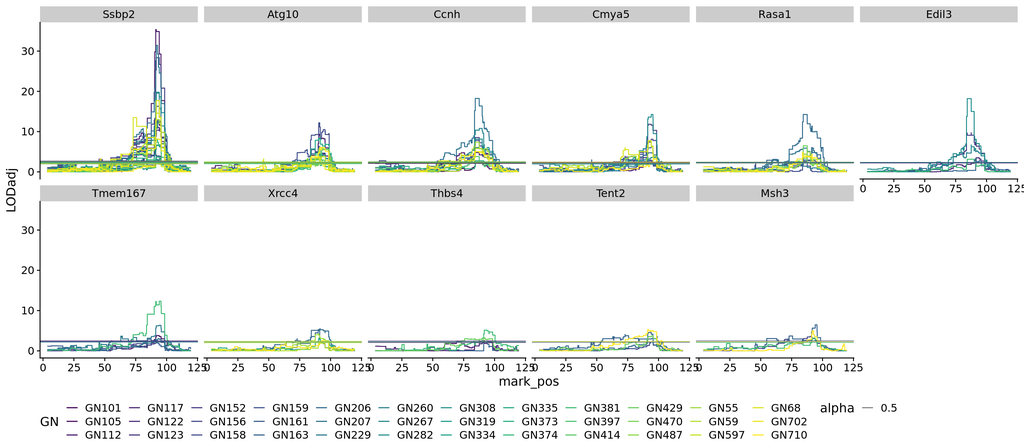

```r
    # this is only necessary when multiple chromosomes
    # p_list = best_trace %>%
    #     semi_join(eqtl_dsets_genes, by = c('GN', 'gene_name')) %>%
    #     # semi_join(qtl_dsets, by = 'GN') %>% # not necessary b/c eqtl_dsets_genes has this filtering already
    #     left_join(gene_ord %>% select(gene_name, Rank), by = 'gene_name') %>%
    #     filter(Rank != other_lvl) %>%
    #     nest(data = !c(gene_name, Rank)) %>%
    #     arrange(Rank) %>%
    #     # slice(1:5) %>%
    #     mutate(p = map2(data, gene_name, function(.x, .y) {
    #         p = .x %>% manhat2(colorGN = TRUE, facetGN = FALSE, chrdiv = FALSE, chrlab = FALSE) +
    #         # p = .x %>% manhat(colorGN = TRUE, facetGN = FALSE) +
    #       guides(color = guide_legend(nrow = 4)) +
    #       theme(legend.position = 'bottom') +
    #       # labs(title = str_c(.y, ' : ', eqtl_db$genes %>% filter(gene_name == .y) %>% pull(gene_chr)))
    #       labs(title = .y, x = 'Chr13 position')
    #         p$layers = c(geom_vline(xintercept = gene_info %>%
    #                        filter(gene_name == .y) %>%
    #                        pull(gene_pos_adj), linetype = 'dashed'),
    #            p$layers)
    #         p
    #     }))
    # lgnd = get_legend(p_list$p[[1]])
    # p_list = p_list %>% mutate(p = map(p, ~.x + theme(legend.position = 'none')))
    # p = plot_grid(plot_grid(plotlist = p_list$p),
    #         plot_grid(NULL, lgnd, nrow = 1, rel_widths = c(0.075, 0.8)),
    #         ncol = 1, rel_heights = c(0.8, 0.1))

    if (0) {
        # every eqtl trace GN/gene_name/probe even if multiple probes per GN
        p = all_trace %>%
            inner_join(probe_max %>% filter(is_eqtl) %>% select(GN, gene_name, probe),
                      by = c('GN', 'gene_name', 'probe')) %>%
            left_join(gene_ord %>% select(gene_name, Rank), by = 'gene_name') %>%
            filter(Rank != other_lvl | gene_name %in% dna_repair_genes) %>%
            mutate(gene_name = fct_reorder(gene_name, as.integer(Rank))) %>%
            ggplot(aes(mark_pos, LODadj, color = str_c(GN, '_', probe))) +
            geom_step() +
            geom_hline(aes(yintercept = thresh, color = GN, alpha = 0.5)) +
            geom_vline(data = ~gene_info %>% semi_join(.x, by = 'gene_name'),
                   aes(xintercept = gene_pos)) +
            scale_color_viridis_d(guide = guide_legend(nrow = 3)) +
            facet_wrap(~gene_name, scales = 'free_y', nrow = 2) +
            theme_half_open() +
            theme(legend.position = 'none')
    } else {
        # single best trace per GN/gene_name (top probe essentially)
        p = best_trace %>%
            semi_join(eqtl_dsets_genes, by = c('GN', 'gene_name')) %>%
            # semi_join(qtl_dsets, by = 'GN') %>% # not necessary b/c eqtl_dsets_genes has this filtering already
            left_join(gene_ord %>% select(gene_name, Rank), by = 'gene_name') %>%
            filter(Rank != other_lvl | gene_name %in% dna_repair_genes) %>%
            mutate(gene_name = fct_reorder(gene_name, as.integer(Rank))) %>%
            ggplot(aes(mark_pos, LODadj, color = GN)) +
            geom_step() +
            geom_hline(aes(yintercept = thresh, color = GN, alpha = 0.5)) +
            # geom_vline(data = ~gene_info %>% semi_join(.x, by = 'gene_name'),
            #      aes(xintercept = gene_pos)) +
            scale_color_viridis_d(guide = guide_legend(nrow = 3)) +
            # facet_wrap(~gene_name, scales = 'free_y', nrow = 2) +
            facet_wrap(~gene_name, nrow = 2) +
            theme_half_open() +
            theme(legend.position = 'bottom')
    }
    p
```

```r
    ggsave('test.pdf', p, w = 16, h = 7)
```

## 19.2 Order by genomic position of the gene

1. Main QTL signal in **black** and per-gene QTL signal in **orange**
2. Meant to visualize closeness of eQTL and QTL peaks for each gene
3. Signal from best dataset for each gene is shown
4. NOTE 02/01/22: removing printing of this

```r
    # get top dataset per gene
    top_dset_per_gene = best_trace %>%
        semi_join(eqtl_dsets_genes, by = c('GN', 'gene_name')) %>%
        left_join(gene_ord %>% select(gene_name, gene_pos, Rank), by = 'gene_name') %>%
        arrange(desc(LODadj)) %>%
        distinct(gene_name, .keep_all = TRUE) %>%
        distinct(GN, gene_name)

    # eQTL traces for top dataset per gene
    eqtl_trace_data = best_trace %>%
        # dense_traces$signal %>% left_join(dense_traces$markers, by = 'marker') %>%
        semi_join(top_dset_per_gene, by = c('GN', 'gene_name')) %>%
        left_join(gene_ord %>% select(gene_name, gene_pos, Rank), by = 'gene_name') %>%
        filter(Rank != other_lvl) %>%
        mutate(gene_name = fct_reorder(gene_name, gene_pos))
        # # rescale - minmax
        # group_by(GN, gene_name) %>%
        # mutate(LODadj = (LODadj - min(LODadj))/(max(LODadj) - min(LODadj))) %>%
        # ungroup

    # QTL data on %expanded phenotype for all strains
    main_qtl_data = final_res$qtl_res %>%
        filter(metric == '% expanded', chr == 'chr13') %>%
        # # rescale - minmax
        # mutate(LODadj = (LODadj - min(LODadj))/(max(LODadj) - min(LODadj))) %>%
        # #
        mutate(across(c(pos, end), ~.x/1e6))

    # QTL data on %expanded phentype gathered for each dset separately using only those strains
    per_dset_qtl_data = top_dset_per_gene %>%
        left_join(perc_expand %>% rename(pos = mark_pos), by = 'GN') %>%
        left_join(gene_ord %>% select(gene_name, gene_pos, Rank), by = 'gene_name') %>%
        mutate(gene_name = fct_reorder(gene_name, gene_pos)) %>%
        filter(Rank != other_lvl)

    # traces plot
    p = eqtl_trace_data %>%
        ggplot(aes(mark_pos, LODadj, color = gene_name)) +
        geom_step() +
        geom_step(data = main_qtl_data, aes(pos, LOD), inherit.aes = FALSE, color = 'black') +
        geom_step(data = per_dset_qtl_data, aes(pos, LOD), inherit.aes = FALSE, color = 'orange') +
        scale_color_viridis_d(guide = guide_legend(nrow = 1)) +
        facet_wrap(~gene_name, nrow = 2) +
        theme_half_open() +
        theme(legend.position = 'bottom')
    # p
    # ggsave('test.pdf', p, w = 16, h = 7)
```

## 19.3 Single panel version

1. Signal from best dataset for each gene is shown

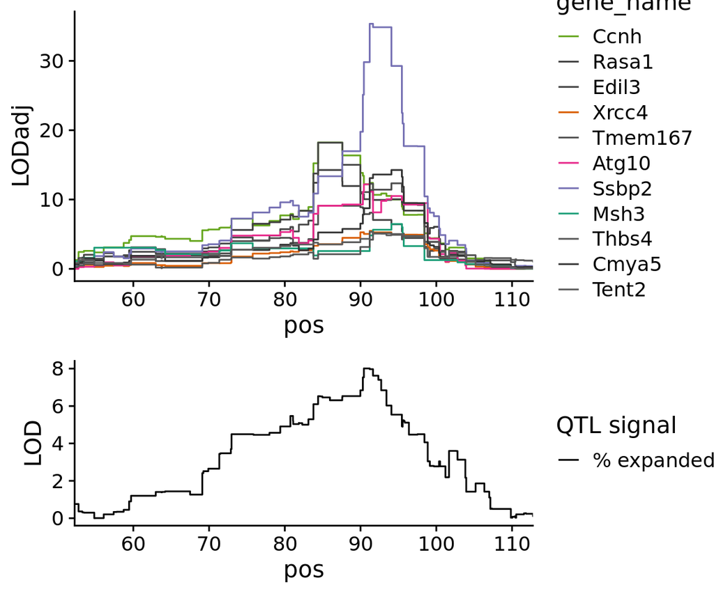

```r
    # xlims = c(0, 125)
    xlims = c(55, 110)
    to_plt = best_trace %>%
        # dense_traces$signal %>% left_join(dense_traces$markers, by = 'marker') %>%
        semi_join(eqtl_dsets_genes, by = c('GN', 'gene_name')) %>%
        left_join(gene_ord %>% select(gene_name, gene_pos, Rank), by = 'gene_name') %>%
        filter(Rank != other_lvl | gene_name %in% dna_repair_genes) %>%
        mutate(gene_name = fct_reorder(gene_name, gene_pos)) %>%
        semi_join(top_dset_per_gene, by = c('GN', 'gene_name')) %>%
        rename(pos = mark_pos)

    p1 = to_plt %>%
        # mutate(gene_name = fct_relevel(gene_name, genes_to_lab)) %>%
        ggplot(aes(pos, LODadj, color = gene_name)) +
        geom_step() +
        # scale_color_brewer(palette = 'Dark2', guide = guide_legend(title = 'eQTL signal')) +
        # scale_color_viridis_d(guide = guide_legend(title = 'eQTL signal')) +
        scale_color_manual(values = gene_pal) +
        coord_cartesian(xlim = xlims) +
        theme_half_open() +
        theme(legend.position = 'right')
    p2 = final_res$qtl_res %>%
        filter(metric == '% expanded', chr == 'chr13') %>%
        mutate(across(c(pos, end), ~.x/1e6)) %>%
        ggplot(aes(pos, LOD, color = metric)) +
        geom_step() +
        scale_color_manual(values = 'black', guide = guide_legend(title = 'QTL signal')) +
        coord_cartesian(xlim = xlims) +
        theme_half_open()
    p = plot_grid(p1, p2, ncol = 1, axis = 'lr', align = 'v', rel_heights = c(1, 0.7))
    p
```

```r
    ggsave('test.pdf', p, w = 6, h = 5)

    # this will be the first panel of a supplementary figure
    psupp_corr_a = p
```

# 20 Colocalization b/w QTL and eQTL signals

## 20.1 Dense-array pre-computed using COLOC

1. Again, best dataset/probe per gene considered
2. eQTL and QTL signals are compared on a per dataset basis, not to main QTL signal using all strains
3. DEPRECATED

```r
    p = dense_coloc$smry %>%
        # join gene name to coloc res (don't have it by default)
        left_join(best_point %>% distinct(GN, probe, gene_name), by = c('GN', 'probe', 'gene_name')) %>%
        semi_join(top_dset_per_gene, by = c('GN', 'gene_name')) %>%
        left_join(gene_ord %>% select(gene_name, gene_pos, Rank), by = 'gene_name') %>%
        filter(Rank != other_lvl) %>%
        mutate(gene_name = fct_reorder(gene_name, gene_pos)) %>%
        pivot_longer(matches('^H\\d'), names_to = 'hypothesis', values_to = 'prob') %>%
        mutate(hypothesis = recode(hypothesis,
                                   H0 = 'no caus var',
                                   H1 = 'caus var in trait1',
                                   H2 = 'caus var in trait2',
                                   H3 = 'diff caus var',
                                   H4 = 'same caus var')) %>%
        ggplot(aes(gene_name, prob, color = hypothesis)) +
        geom_point() +
        geom_line(aes(group = hypothesis)) +
        scale_color_brewer(palette = 'Dark2') +
        theme_half_open() +
        theme(axis.text.x = element_text(angle = 90, hjust = 1, vjust = 0.5),
              axis.title.x = element_blank(),
              legend.position = c(0.9, 0.8),
              legend.justification = c(1, 1)
        )
    p
    ggsave('test.pdf', p, w = 8, h = 5)
```

## 20.2 Simple way by taking LD b/w markers

### 20.2.1 Top dset per gene

1. Again, best dataset/probe per gene considered
2. `main_qtl` is using all strains
3. `per_dset_qtl`: using strains available per dataset
4. NOTE 02/01/22: removing printing of this

```r
    # combine qtl and eqtl signal traces for dataset of interest
    qtl_eqtl_signals_comb = list(
        main_qtl     = main_qtl_data %>%
            mutate(across(c(pos, end), ~.x*1e6)) %>%
            unite('marker', c('chr', 'pos', 'end')) %>%
            select(marker, LOD) %>%
            crossing(eqtl_dsets_genes),
        per_dset_qtl = perc_expand %>%
            rename(pos = mark_pos) %>%
            inner_join(eqtl_dsets_genes, by = 'GN') %>%
            select(GN, gene_name, marker, LOD),
        eqtl         = best_trace %>%
            inner_join(eqtl_dsets_genes, by = c('GN', 'gene_name')) %>%
            select(GN, gene_name, marker, LOD = LODadj)
    ) %>% map_df(~.x, .id = 'trace_type')

    # find the lead marker for the main QTL, per-gene QTL and eQTL for every dset/gene pair of interest
    lead_mark_per_dset_qtl_eqtl = qtl_eqtl_signals_comb  %>%
        left_join(gene_ord %>% select(gene_name, gene_pos, Rank), by = 'gene_name') %>%
        mutate(gene_name = fct_reorder(gene_name, gene_pos)) %>%
        filter(Rank != other_lvl) %>%
        # keep best marker with top LOD for each trace_type
        arrange(desc(LOD)) %>%
        distinct(trace_type, gene_name, GN, .keep_all = TRUE, with_ties = FALSE)

    # calculate the LD between these markers for each dset/gene pair of interest
    qtl_eqtl_mark_cor = lead_mark_per_dset_qtl_eqtl %>%
        # join genotypes
        left_join(bxd_mark_gts, by = 'marker') %>%
        # run correlation for each GN separately
        nest(data = !c(GN, gene_name)) %>%
        mutate(data = map(data, function(.x) {
            .x = .x %>%
                # pivot so that strains are rows, trace_type (by proxy marker) are columns and genotypes are values
                pivot_wider(id_cols = strain, names_from = trace_type, values_from = fou_gt) %>%
                as.data.frame %>% column_to_rownames(var = 'strain')
            .x = .x %>% cor(method = 'pearson', use = 'pairwise.complete')
            .x = .x[c('main_qtl', 'per_dset_qtl', 'eqtl'), c('main_qtl', 'per_dset_qtl', 'eqtl')]
            .x[upper.tri(.x, diag = TRUE)] = NA
            .x %>% as.data.frame %>% rownames_to_column(var = 'mark1') %>%
                as_tibble %>%
                pivot_longer(cols = !mark1, names_to = 'mark2', values_to = 'lead_snp_cor') %>%
                filter(!is.na(lead_snp_cor))
        })) %>%
        unnest(data)

    p = qtl_eqtl_mark_cor %>%
        semi_join(top_dset_per_gene, by = c('GN', 'gene_name')) %>%
        ggplot(aes(gene_name, lead_snp_cor)) +
        geom_bar(stat = 'identity') +
        facet_wrap(~mark1+mark2) +
        theme_half_open() +
        theme(axis.text.x = element_text(angle = 90, hjust = 1, vjust = 0.5))
    # p
    # ggsave('test.pdf', p, w = 8, h = 5)
```

### 20.2.2 All dset/gene pairs

1. Instead of using only top dataset per gene, calculate the LD b/w lead QTL/eQTL snps for each dset/gene pair with eQTL
2. Lead snps may slightly different, between datasets
3. NOTE 02/01/22: removing printing of this

```r
    p = qtl_eqtl_mark_cor %>%
        ggplot(aes(gene_name, lead_snp_cor)) +
        geom_boxplot() +
        geom_quasirandom(groupOnX = TRUE) +
        facet_wrap(~mark1+mark2) +
        theme_half_open() +
        theme(axis.text.x = element_text(angle = 90, hjust = 1, vjust = 0.5))
    # p
    # ggsave('test.pdf', p, w = 8, h = 5)
```

## 20.3 Correlation b/w traces

1. Not just the lead snp
2. `aov` gene by `qtl_eqtl_cor` is not significant

```r
    # visualize correlations for testing purposes
    if (0) {
        p = qtl_eqtl_signals_comb %>%
            pivot_wider(id_cols = c(GN, marker, gene_name), names_from = trace_type, values_from = LOD) %>%
            # filter(gene_name == 'Msh3', GN == 'GN381') %>%
            # filter(gene_name == 'Msh3') %>%
            # filter(GN == 'GN381') %>%
            ggplot(aes(per_dset_qtl, eqtl, color = GN)) +
            geom_point() +
            geom_smooth(method = 'lm') +
            facet_wrap(~gene_name, scales = 'free') +
            theme_half_open()
        ggsave('test.pdf', p, w = 16, h = 10)
    }

    # calculate correlation between signals, marker per marker
    calc_corr = function(data, x_var, y_var) {
        cor(data[,x_var], data[,y_var], method = 'pearson', use = 'pairwise.complete.obs')
    }
    signal_signal_cor = qtl_eqtl_signals_comb %>%
        left_join(gene_ord %>% select(gene_name, gene_pos, Rank), by = 'gene_name') %>%
        mutate(gene_name = fct_reorder(gene_name, gene_pos)) %>%
        filter(Rank != other_lvl | gene_name %in% dna_repair_genes) %>%
        pivot_wider(id_cols = c(GN, marker, gene_name), names_from = trace_type, values_from = LOD) %>%
        nest(data = !c(GN, gene_name)) %>%
        mutate(main_qtl_eqtl_cor = map_dbl(data, ~calc_corr(.x, 'main_qtl', 'eqtl')),
               per_dset_qtl_eqtl_cor = map_dbl(data, ~calc_corr(.x, 'per_dset_qtl', 'eqtl'))
        ) %>%
        select(!data)
```

### 20.3.1 eQTL vs. per-dset QTL (finalized)

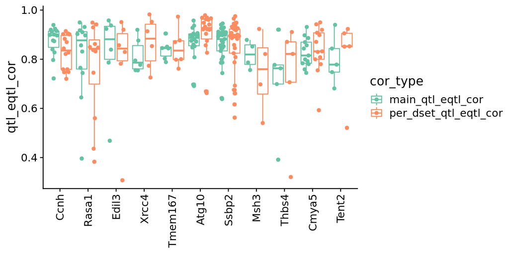

```r
    pos = position_dodge(width = 0.9)
    p = signal_signal_cor %>%
        pivot_longer(!c(GN, gene_name), names_to = 'cor_type', values_to = 'qtl_eqtl_cor') %>%
        ggplot(aes(gene_name, qtl_eqtl_cor, color = cor_type)) +
        geom_boxplot(position = pos) +
        geom_quasirandom(groupOnX = TRUE, dodge.width = 0.9) +
        scale_color_brewer(palette = 'Set2') +
        theme_half_open() +
        theme(
            axis.text.x = element_text(angle = 90, hjust = 1, vjust = 0.5),
            axis.title.x = element_blank()
        )
    p
```

```r
    ggsave('test.pdf', p, w = 8, h = 4)
```

### 20.3.2 eQTL vs. main QTL (finalized)

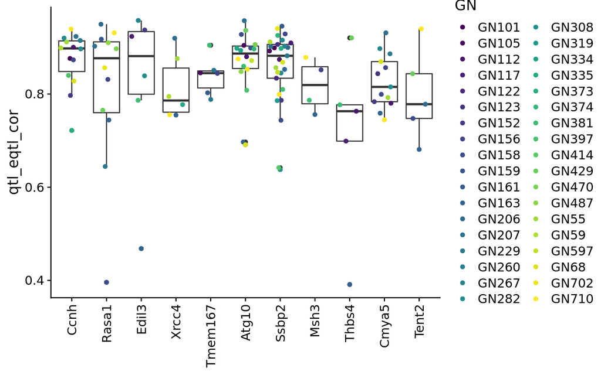

```r
    p = signal_signal_cor %>%
        pivot_longer(!c(GN, gene_name), names_to = 'cor_type', values_to = 'qtl_eqtl_cor') %>%
        filter(cor_type == 'main_qtl_eqtl_cor') %>%
        ggplot(aes(gene_name, qtl_eqtl_cor)) +
        geom_boxplot() +
        geom_quasirandom(aes(color = GN), groupOnX = TRUE) +
        scale_color_viridis_d() +
        # facet_wrap(~cor_type) +
        theme_half_open() +
        theme(
            axis.text.x = element_text(angle = 90, hjust = 1, vjust = 0.5),
            axis.title.x = element_blank()
        )
    p
```

```r
    ggsave('test.pdf', p, w = 8, h = 6)

    # test for significance by ANOVA
    signal_signal_cor %>%
        pivot_longer(!c(GN, gene_name), names_to = 'cor_type', values_to = 'qtl_eqtl_cor') %>%
        filter(cor_type == 'main_qtl_eqtl_cor') %>%
        aov(qtl_eqtl_cor ~ gene_name, data = .) %>%
        broom::tidy()
```

| term | df | sumsq | meansq | statistic | p.value |
| --- | --- | --- | --- | --- | --- |
| gene_name | 10 | 0.1502891 | 0.015028912 | 1.565401 | 0.1268765 |
| Residuals | 107 | 1.0272729 | 0.009600681 | NA | NA |

# 21 eQTL traces for DNA repair genes (for final figure)

1. These are genes which have known relevant function to DNA repair
2. Only datasets where eQTL signal is significant

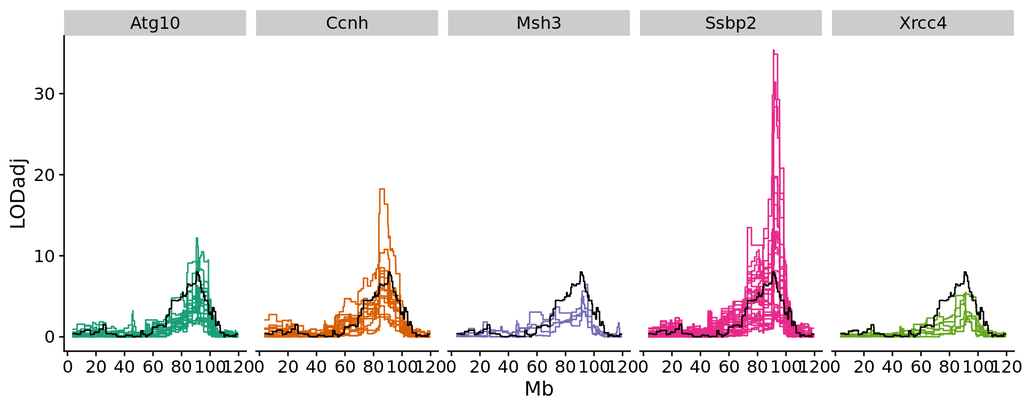

```r
    top_signals = best_trace %>%
        filter(gene_name %in% dna_repair_genes) %>%
        semi_join(eqtl_dsets_genes, by = c('GN', 'gene_name')) %>%
        # semi_join(qtl_dsets, by = 'GN') %>% # not necessary b/c eqtl_dsets_genes has this filtering already
        group_by(gene_name, GN) %>%
        mutate(maxLOD = max(LODadj)) %>%
        ungroup
    p = ggplot() +
        geom_step(data = top_signals,
                  # aes(mark_pos, LODadj, group = GN, alpha = maxLOD, color = gene_name)) +
                  aes(mark_pos, LODadj, group = GN, color = gene_name)) +
        geom_step(data = final_res$qtl_res %>%
                      filter(metric == '% expanded', chr == 'chr13') %>%
                      mutate(across(c(pos, end), ~.x/1e6)),
                  aes(pos, LOD), inherit.aes = FALSE) +
        scale_color_brewer(palette = 'Dark2') +
        scale_fill_brewer(palette = 'Dark2') +
        scale_x_continuous(breaks = scales::breaks_pretty()) +
        facet_wrap(~gene_name, nrow = 1) +
        theme_half_open() +
        theme(legend.position = 'none'
              # panel.spacing = unit(0.5, 'lines')
        ) +
        labs(x = 'Mb')
    p
```

```r
    ggsave('test.pdf', p, w = 10, h = 4)

    p_c = p
```

1. NOTE: THIS SECTION IS ONLY FOR TROUBLESHOOTING AND IS HIDDEN
2. Check the selection of those GN/dset combinations with significant peaks
3. Panels w/ significant peaks are boxed

```r
    p_list = best_trace %>%
        filter(gene_name %in% dna_repair_genes) %>%
        semi_join(qtl_dsets, by = 'GN') %>%
        left_join(eqtl_dsets_genes %>% mutate(is_signif = TRUE), by = c('GN', 'gene_name')) %>%
        mutate(is_signif = replace_na(is_signif, FALSE)) %>%
        # split into two groups
        mutate(uid = cut_interval(as.integer(as.factor(GN)), 2, label = FALSE)) %>%
        nest(data = !uid) %>%
        mutate(p = map(data,
            ~.x %>%
                ggplot(aes(mark_pos, LODadj, color = gene_name)) +
                geom_hline(aes(yintercept = thresh), linetype = 'dashed') +
                geom_step() +
                geom_rect(data = ~.x %>% filter(is_signif),
                          xmin = -Inf, xmax = Inf, ymin = -Inf, ymax = Inf,
                          color = 'gray30', alpha = 0.5, fill = NA, size = 2) +
                coord_cartesian(ylim = c(0, NA)) +
                scale_color_viridis_d() +
                facet_grid2(gene_name~GN, scales = 'free_y', axes = 'margins', independent = 'none') +
                theme_half_open() +
                theme(
                    panel.spacing = unit(1, 'pt'),
                    legend.position = 'bottom',
                    strip.text.y.right = element_text(angle = 0),
                    axis.text.x = element_blank(),
                    axis.ticks.x = element_blank()
                )
        ))
    p = plot_grid(plotlist = p_list$p, nrow = 2)

    p
    # ggsave('test.pdf', p, w = 16, h = 10)
```

# 22 Export data

```r
    cache_dir = '../data/analysis_cache'
    out_file = path(cache_dir, 'eqtl_data.rds')
    to_save = list(
        qtl_dsets         = qtl_dsets, # dsets that support a QTL signal`
        eqtl_dsets_genes  = eqtl_dsets_genes, # dset/gene pairs that have eqtl signal
        gene_ord          = gene_ord, # ranked genes by number of dsets with eQTL signal
        # unq_expr_vals     = unq_expr_vals, # unique expression values aggregated in different ways
        best_trace        = best_trace,
        best_point        = best_point,
        probe_max         = probe_max,
        sel_dsets         = sel_dsets,
        common_prot_genes = common_prot_genes,
        gene_pal          = gene_pal,
        signal_signal_cor = signal_signal_cor
    )
    saveRDS(to_save, out_file)
```